# Chapter6

Pekka Tolli

7 December 2018

# Week 6 - Longitudinal set of rats featuring pipe(r) of Hameln

This is the last IODS exercise for now. Time for longitudinal analysis of rats and humans, featuring some pipe(r) functions (stupid pun intended).

## Part 1 RATS:

On this first part I’ll analyse the longitudinal rats data set by Kimmo Vehkalahti from a nutrition study on three groups of rats. The data each rat’s weight being recorded once a week for 9 weeks. Thus the data is longitudinal, i.e. it tracks each rat over a time period. I will test if the nutrition changes have impact on the weight change of a rat.

```r
RATSL <- read.csv("C:/Users/pekka/Documents/GitHub/IODS-project/Data/rats.txt", sep  ="\t", header = T)

RATSL$Group <- factor(RATSL$Group)
RATSL$ID <- factor(RATSL$ID)

str(RATSL)
```

```
## 'data.frame':    176 obs. of  5 variables:
##  $ ID    : Factor w/ 16 levels "1","2","3","4",..: 1 2 3 4 5 6 7 8 9 10 ...
##  $ Group : Factor w/ 3 levels "1","2","3": 1 1 1 1 1 1 1 1 2 2 ...
##  $ WD    : Factor w/ 11 levels "WD1","WD15","WD22",..: 1 1 1 1 1 1 1 1 1 1 ...
##  $ Weight: int  240 225 245 260 255 260 275 245 410 405 ...
##  $ Time  : int  1 1 1 1 1 1 1 1 1 1 ...
```

```r
dim(RATSL)
```

```
## [1] 176   5
```

```r
summary(RATSL)
```

```
##        ID      Group        WD         Weight           Time
##  1      : 11   1:88   WD1    :16   Min.   :225.0   Min.   : 1.00
##  2      : 11   2:44   WD15   :16   1st Qu.:267.0   1st Qu.:15.00
##  3      : 11   3:44   WD22   :16   Median :344.5   Median :36.00
##  4      : 11          WD29   :16   Mean   :384.5   Mean   :33.55
##  5      : 11          WD36   :16   3rd Qu.:511.2   3rd Qu.:50.00
##  6      : 11          WD43   :16   Max.   :628.0   Max.   :64.00
##  (Other):110          (Other):80
```

```r
head(RATSL)
```

```
##   ID Group  WD Weight Time
## 1  1     1 WD1    240    1
## 2  2     1 WD1    225    1
## 3  3     1 WD1    245    1
## 4  4     1 WD1    260    1
## 5  5     1 WD1    255    1
## 6  6     1 WD1    260    1
```

We have data set with 5 variables and 176 rows containing observations of 16 rats across 9 weeks of time.

## Visualizing RATS data

Let’s draw basic line charts of the unstandardized RATS data classified by nutrition group:

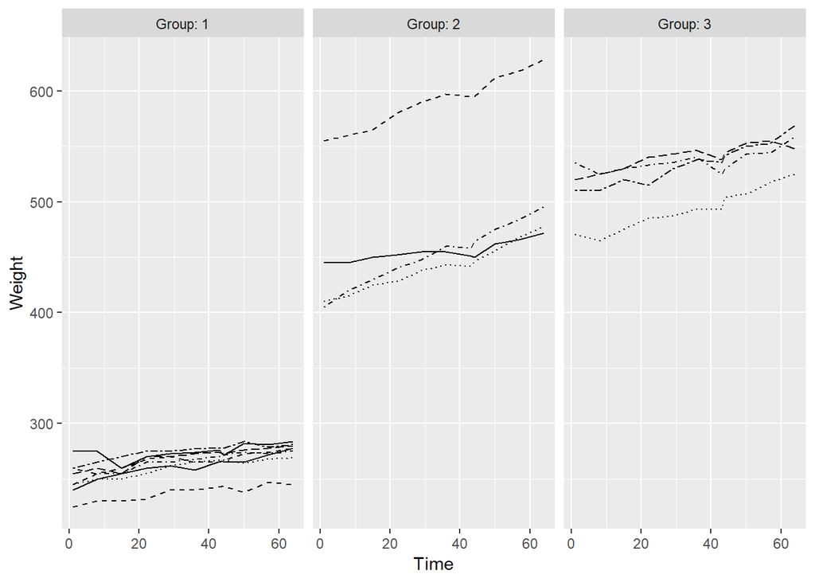

```r
ggplot(RATSL, aes(x = Time, y = Weight, linetype = ID)) +
  geom_line() +
  scale_linetype_manual(values = rep(1:10, times=4)) +
  facet_grid(. ~ Group, labeller = label_both) +
  theme(legend.position = "none") +
  scale_y_continuous(limits = c(min(RATSL$Weight), max(RATSL$Weight)))
```

A couple of observations emerge: First, practically all rats have increased their weight during the study. Second, group 1 rats were lighter at the beginning and the end of the study. Third, group 2 has a potential outlier (a big rat).

## Standardizing the RATS data

To do proper analysis, let’s standardize the data:

```r
RATSL <- RATSL %>%
  group_by(Time) %>%
  mutate(standard_RATSL = (Weight - mean(Weight))/sd(Weight) ) %>%
  ungroup()
glimpse(RATSL)
```

```
## Observations: 176
## Variables: 6
## $ ID             <fct> 1, 2, 3, 4, 5, 6, 7, 8, 9, 10, 11, 12, 13, 14, ...
## $ Group          <fct> 1, 1, 1, 1, 1, 1, 1, 1, 2, 2, 2, 2, 3, 3, 3, 3,...
## $ WD             <fct> WD1, WD1, WD1, WD1, WD1, WD1, WD1, WD1, WD1, WD...
## $ Weight         <int> 240, 225, 245, 260, 255, 260, 275, 245, 410, 40...
## $ Time           <int> 1, 1, 1, 1, 1, 1, 1, 1, 1, 1, 1, 1, 1, 1, 1, 1,...
## $ standard_RATSL <dbl> -1.0011429, -1.1203857, -0.9613953, -0.8421525,...
```

And let’s see again how the standardized data looks like:

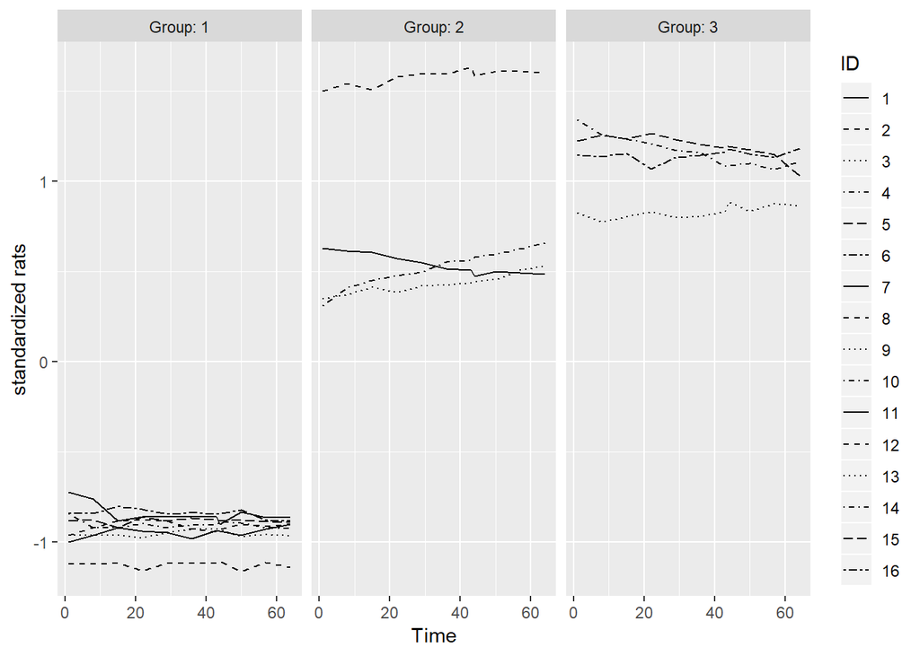

```r
ggplot(RATSL, aes(x = Time, y = standard_RATSL, linetype = ID)) +
  geom_line() +
  scale_linetype_manual(values = rep(1:10, times=4)) +
  facet_grid(. ~ Group, labeller = label_both) +
  scale_y_continuous(name = "standardized rats")
```

We now can see that Y-axis has the universal scale, as weight is scaled for all groups. So we did not loose the variability inside the groups but we made data a bit more homogenious between the groups. Now we will make another plot, checking groups by weight mean values across time.

```r
n <- RATSL$Time %>% unique() %>% length()
RATSS <- RATSL %>%
  group_by(Group, Time) %>%
  summarise( mean = mean(Weight), se = sd(Weight)/sqrt(n) ) %>%
  ungroup()
glimpse(RATSS)
```

```
## Observations: 33
## Variables: 4
## $ Group <fct> 1, 1, 1, 1, 1, 1, 1, 1, 1, 1, 1, 2, 2, 2, 2, 2, 2, 2, 2,...
## $ Time  <int> 1, 8, 15, 22, 29, 36, 43, 44, 50, 57, 64, 1, 8, 15, 22, ...
## $ mean  <dbl> 250.625, 255.000, 254.375, 261.875, 264.625, 265.000, 26...
## $ se    <dbl> 4.589478, 3.947710, 3.460116, 4.100800, 3.333956, 3.5529...
```

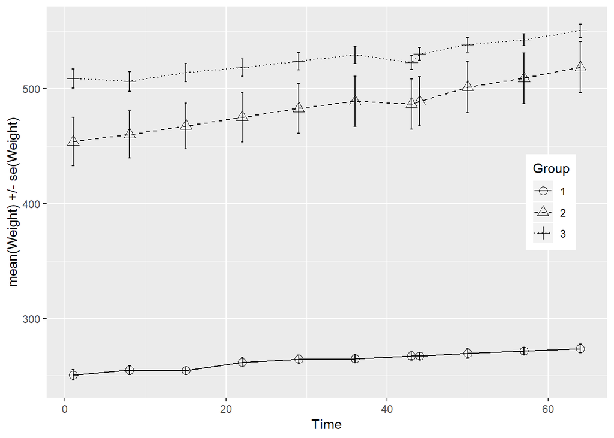

```r
ggplot(RATSS, aes(x = Time, y = mean, linetype = Group, shape = Group)) +
  geom_line() +
  scale_linetype_manual(values = c(1,2,3)) +
  geom_point(size=3) +
  scale_shape_manual(values = c(1,2,3)) +
  geom_errorbar(aes(ymin = mean - se, ymax = mean + se, linetype="1"), width=0.3) +
  theme(legend.position = c(0.9,0.5)) +
  scale_y_continuous(name = "mean(Weight) +/- se(Weight)")
```

Now we see the plot for three groups by weight mean values and it gives a very nice overview of three groups against each other. As in previous lines, we see that Group 1 has lowest mean of weight, while Groups 2 and 3 are closer to each other.

## Removing outliers

Lets see if the data has any outliers. If yes, remove them.

```r
RATSL8S <- RATSL %>%
  filter(Time > 0) %>%
  group_by(Group, ID) %>%
  summarise( mean=mean(Weight) ) %>%
  ungroup()
glimpse(RATSL8S)
```

```
## Observations: 16
## Variables: 3
## $ Group <fct> 1, 1, 1, 1, 1, 1, 1, 1, 2, 2, 2, 2, 3, 3, 3, 3
## $ ID    <fct> 1, 2, 3, 4, 5, 6, 7, 8, 9, 10, 11, 12, 13, 14, 15, 16
## $ mean  <dbl> 261.0909, 237.6364, 260.1818, 266.5455, 269.4545, 274.72...
```

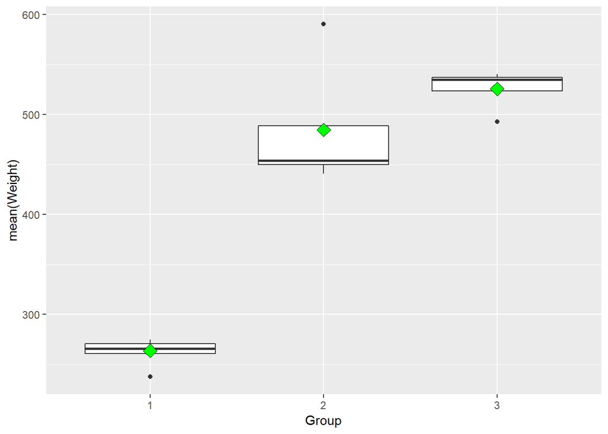

```r
ggplot(RATSL8S, aes(x = Group, y = mean)) +
  geom_boxplot() +
  stat_summary(fun.y = "mean", geom = "point", shape=23, size=4, fill = "green") +
  scale_y_continuous(name = "mean(Weight)")
```

In group 2 there is one quite far off from the others as pointed out in the initial observation. Let’s remove it

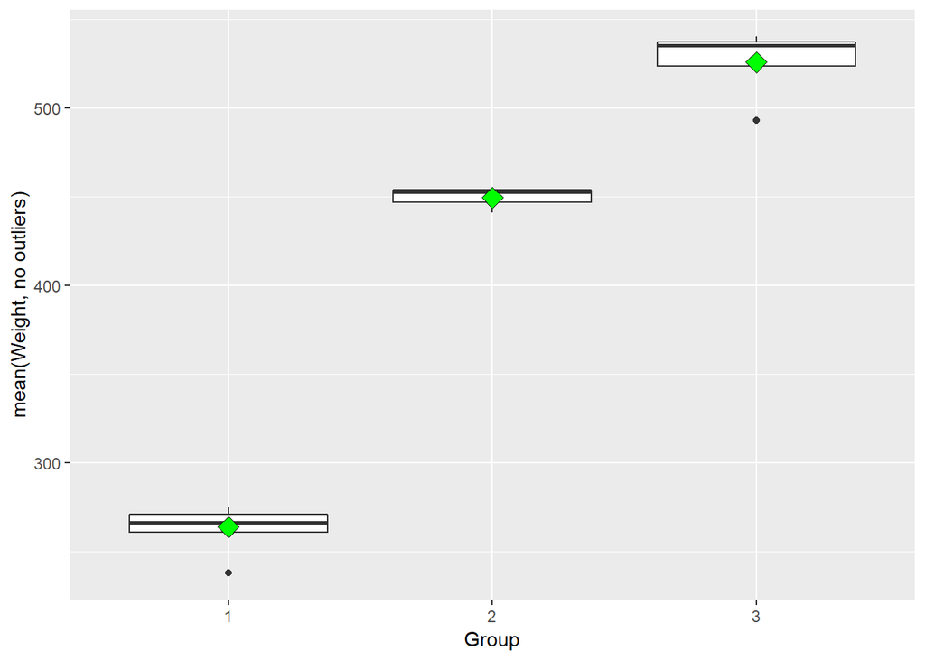

```r
RATSL8S1 <- RATSL8S %>%
  filter(mean < 550)
ggplot(RATSL8S1, aes(x = Group, y = mean)) +
  geom_boxplot() +
  stat_summary(fun.y = "mean", geom = "point", shape=23, size=4, fill = "green") +
  scale_y_continuous(name = "mean(Weight, no outliers)")
```